# Homework 04

## Question 1: Signal strength and correlated substitutes

### Answer

**Note**

**A note on random-number generation.** The simulation below draws with `rng = np.random.default_rng(43246)` (NumPy’s modern `Generator` API) rather than the legacy `np.random.seed()` + `np.random.randn()` pattern. This matters here specifically because `sklearn.linear_model.Lasso`/`ElasticNet` call `check_random_state(None)` internally on every `.fit()` call — even under the default `selection="cyclic"` — which silently advances the *legacy* global RNG’s internal position. With the legacy pattern, that means the exact sequence of simulated datasets would depend on how many models get fit per repetition, so Question 1 (one lasso fit per repetition/penalty) and Question 2 (lasso *and* elastic net) would silently end up simulating different data even with the same seed — breaking the requirement that both questions “produce the same datasets.” A `default_rng()` generator is a separate, local object that `.fit()` never touches, so this can’t happen.

#### Part a

```
All 800 fits converged: True
```

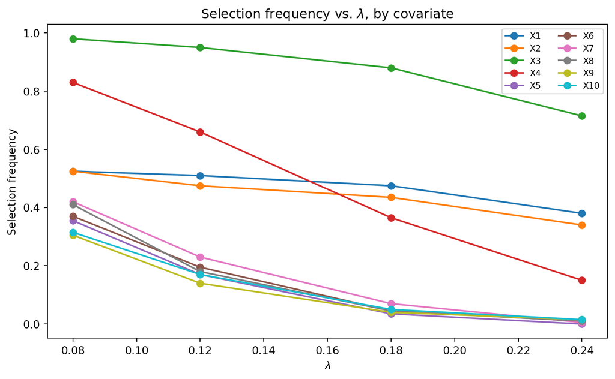

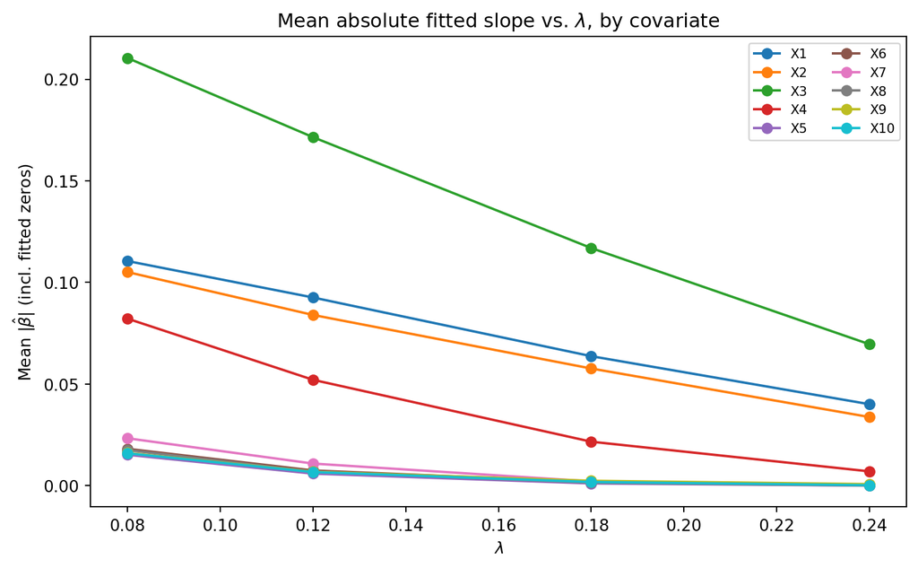

Table 1: Selection frequency by covariate and $\lambda$.

|  | $\lambda=0.08$ | $\lambda=0.12$ | $\lambda=0.18$ | $\lambda=0.24$ |
| --- | --- | --- | --- | --- |
| X1 | 0.525 | 0.510 | 0.475 | 0.380 |
| X2 | 0.525 | 0.475 | 0.435 | 0.340 |
| X3 | 0.980 | 0.950 | 0.880 | 0.715 |
| X4 | 0.830 | 0.660 | 0.365 | 0.150 |
| X5 | 0.355 | 0.170 | 0.035 | 0.000 |
| X6 | 0.370 | 0.195 | 0.045 | 0.010 |
| X7 | 0.420 | 0.230 | 0.070 | 0.005 |
| X8 | 0.410 | 0.180 | 0.045 | 0.010 |
| X9 | 0.305 | 0.140 | 0.040 | 0.015 |
| X10 | 0.315 | 0.170 | 0.050 | 0.015 |

Table 2: Mean $|\hat\beta_j|$ (including fitted zeros) by covariate and $\lambda$.

|  | $\lambda=0.08$ | $\lambda=0.12$ | $\lambda=0.18$ | $\lambda=0.24$ |
| --- | --- | --- | --- | --- |
| X1 | 0.1105 | 0.0926 | 0.0637 | 0.0401 |
| X2 | 0.1051 | 0.0840 | 0.0576 | 0.0338 |
| X3 | 0.2105 | 0.1715 | 0.1169 | 0.0696 |
| X4 | 0.0822 | 0.0521 | 0.0216 | 0.0070 |
| X5 | 0.0152 | 0.0059 | 0.0011 | 0.0000 |
| X6 | 0.0181 | 0.0075 | 0.0017 | 0.0004 |
| X7 | 0.0233 | 0.0109 | 0.0021 | 0.0002 |
| X8 | 0.0174 | 0.0068 | 0.0015 | 0.0001 |
| X9 | 0.0161 | 0.0068 | 0.0024 | 0.0007 |
| X10 | 0.0159 | 0.0067 | 0.0018 | 0.0002 |

As $\lambda$ increases from $0.08$ to $0.24$, mean $|\hat\beta_j|$ falls monotonically for *every* covariate (Table , figures above) — the usual $\ell_1$ shrinkage/soft-thresholding effect. Selection frequency (Table , figures above) falls for every covariate as $\lambda$ grows, but at very different rates. $X_3$ (true coefficient $0.30$) is selected in essentially every replicate at the smallest penalty ($0.980$) and remains the most frequently selected covariate throughout, still at $0.715$ at $\lambda = 0.24$. $X_1$, $X_2$, and $X_4$ (true coefficient $0.15$ each) start noticeably lower ($0.53$–$0.83$) and fall faster, with $X_4$ collapsing to $0.150$ by $\lambda=0.24$. The pure noise covariates $X_5,\dots,X_{10}$ (true coefficient $0$) start around $0.31$–$0.42$ at $\lambda = 0.08$ — nontrivial, since with $n=120$ and ten correlated-with-noise draws some spurious selection is expected at a small penalty — but are driven toward zero rapidly, averaging about $0.05$ by $\lambda = 0.18$ and under $0.01$ by $\lambda = 0.24$. This ordering matches the size of the true coefficient: a larger true signal survives a larger penalty before its estimated effect is shrunk below the point where it gets thresholded to exactly zero.

#### Part b

```
lambda=0.08: only_X1=0.465 only_X2=0.465 both=0.060 neither=0.010
lambda=0.12: only_X1=0.475 only_X2=0.440 both=0.035 neither=0.050
lambda=0.18: only_X1=0.445 only_X2=0.405 both=0.030 neither=0.120
lambda=0.24: only_X1=0.350 only_X2=0.310 both=0.030 neither=0.310
```

Table 3: Joint and marginal selection outcomes for $(X_1,X_2)$.

|  | Only $X_1$ | Only $X_2$ | Both | Neither |
| --- | --- | --- | --- | --- |
| $\lambda=0.08$ | 0.465 | 0.465 | 0.060 | 0.01 |
| $\lambda=0.12$ | 0.475 | 0.440 | 0.035 | 0.05 |
| $\lambda=0.18$ | 0.445 | 0.405 | 0.030 | 0.12 |
| $\lambda=0.24$ | 0.350 | 0.310 | 0.030 | 0.31 |

As $\lambda$ increases, **both selected** declines from $0.060$ to $0.030$ while **neither selected** rises sharply, from $0.010$ at $\lambda=0.08$ to $0.310$ at $\lambda=0.24$; **only $X_1$** and **only $X_2$** remain the dominant outcomes at the smaller penalties, together accounting for over $90\%$ of replicates at $\lambda=0.08$, though that combined share falls to about $66\%$ by $\lambda=0.24$ as **neither** grows. This is the signature lasso behavior under near-collinearity: because $X_1$ and $X_2$ are almost interchangeable predictors, the $\ell_1$ penalty makes it cheaper to load the shared effect onto a single member of the pair and zero out the other than to keep two nearly redundant coefficients active simultaneously. Which one “wins” is sensitive to the noise realization in a given replicate, producing a sparse fitted rule that omits one member of the pair even though *both* appear with equal weight ($0.15$ each) in the true generating equation. As $\lambda$ grows further, it becomes cheap enough to drop even the single retained variable, so **neither** grows to over $30\%$ of replicates by $\lambda=0.24$ while **both** falls to half its $\lambda=0.08$ level.

#### Part c

Table 4: Selection frequency: $X_3$, $X_4$, and average over $X_5,\dots,X_{10}$.

|  | $X_3$ | $X_4$ | avg($X_5,\dots,X_{10}$) |
| --- | --- | --- | --- |
| $\lambda=0.08$ | 0.980 | 0.830 | 0.362 |
| $\lambda=0.12$ | 0.950 | 0.660 | 0.181 |
| $\lambda=0.18$ | 0.880 | 0.365 | 0.048 |
| $\lambda=0.24$ | 0.715 | 0.150 | 0.009 |

At every $\lambda$, $\text{freq}(X_3) > \text{freq}(X_4) \gg \text{avg. freq}(X_5,\dots,X_{10})$ (Table ): at $\lambda=0.08$ this is $0.980$ vs. $0.830$ vs. $0.362$, and by $\lambda=0.24$ the gap has widened in relative terms to $0.715$ vs. $0.150$ vs. $0.009$. This tracks the ordering of true coefficient magnitude ($\beta_3=0.30 > \beta_4=0.15 > \beta_5=\dots=\beta_{10}=0$): a larger true coefficient produces a larger, more reliably detectable in-sample correlation with $Y$, so a larger $\lambda$ is required to push its estimate below the soft-threshold. The noise block’s average frequency is not negligible at the smallest penalty ($0.362$) — with ten covariates and $n=120$, a few spurious correlations are expected to survive a weak penalty — but it decays roughly forty-fold from $\lambda=0.08$ to $\lambda=0.24$, confirming that penalty strength is doing most of the work of separating signal from noise once $\lambda$ is large enough.

The $(X_1,X_2)$ results show why a fitted zero does not establish that the population coefficient is zero, and a nonzero fit does not establish unique importance. In a replicate where lasso selects only $X_2$, the true $\beta_1 = 0.15$ is identical to $\beta_2$ — $X_1$ is just as related to $Y$ marginally, but was dropped only because $X_2$ already absorbs nearly the same information. Symmetrically, the nonzero $\hat\beta_2$ in that replicate is not evidence that $X_2$ uniquely drives $Y$: it stands in for a shared effect that could equally have been attributed to $X_1$ in a different sample, as the near-equal magnitudes of **only $X_1$** ($0.465$ at $\lambda=0.08$) and **only $X_2$** ($0.465$) in Table confirm. Under high correlation, lasso’s selection pattern reflects which member of a redundant group happened to be picked in that sample — not which variable is structurally “the” important one.

## Question 2: Elastic net with an equal penalty mix

### Answer

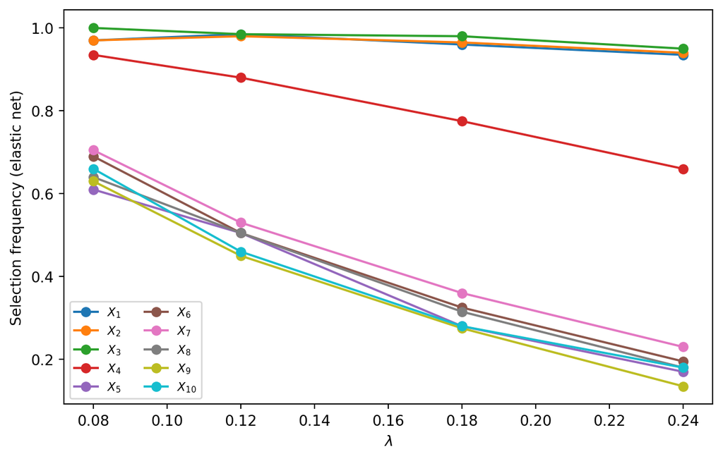

Figure 1: Elastic net selection frequency vs. $\lambda$, by covariate.

Lasso: all 800 fits converged: **True**. Elastic net: all 800 fits converged: **True**.

#### Part a

Table 5: Elastic net ($\alpha=0.5$) selection frequency by covariate and $\lambda$.

|  | 0.08 | 0.12 | 0.18 | 0.24 |
| --- | --- | --- | --- | --- |
| $X_{1}$ | 0.970 | 0.985 | 0.960 | 0.935 |
| $X_{2}$ | 0.970 | 0.980 | 0.965 | 0.940 |
| $X_{3}$ | 1.000 | 0.985 | 0.980 | 0.950 |
| $X_{4}$ | 0.935 | 0.880 | 0.775 | 0.660 |
| $X_{5}$ | 0.610 | 0.505 | 0.280 | 0.170 |
| $X_{6}$ | 0.690 | 0.505 | 0.325 | 0.195 |
| $X_{7}$ | 0.705 | 0.530 | 0.360 | 0.230 |
| $X_{8}$ | 0.640 | 0.505 | 0.315 | 0.180 |
| $X_{9}$ | 0.630 | 0.450 | 0.275 | 0.135 |
| $X_{10}$ | 0.660 | 0.460 | 0.280 | 0.180 |

Table 6: Elastic net minus lasso selection frequency, same datasets ($n=120$).

|  | 0.08 | 0.12 | 0.18 | 0.24 |
| --- | --- | --- | --- | --- |
| $X_{1}$ | +0.445 | +0.475 | +0.485 | +0.555 |
| $X_{2}$ | +0.445 | +0.505 | +0.530 | +0.600 |
| $X_{3}$ | +0.020 | +0.035 | +0.100 | +0.235 |
| $X_{4}$ | +0.105 | +0.220 | +0.410 | +0.510 |
| $X_{5}$ | +0.255 | +0.335 | +0.245 | +0.170 |
| $X_{6}$ | +0.320 | +0.310 | +0.280 | +0.185 |
| $X_{7}$ | +0.285 | +0.300 | +0.290 | +0.225 |
| $X_{8}$ | +0.230 | +0.325 | +0.270 | +0.170 |
| $X_{9}$ | +0.325 | +0.310 | +0.235 | +0.120 |
| $X_{10}$ | +0.345 | +0.290 | +0.230 | +0.165 |

#### Part b

Table 7: Elastic net: joint and marginal selection outcomes for $(X_1,X_2)$.

| $\lambda$ | Only $X_1$ | Only $X_2$ | Both | Neither | Marg. $X_1$ | Marg. $X_2$ |
| --- | --- | --- | --- | --- | --- | --- |
| 0.08 | 0.025 | 0.025 | 0.945 | 0.005 | 0.970 | 0.970 |
| 0.12 | 0.015 | 0.010 | 0.970 | 0.005 | 0.985 | 0.980 |
| 0.18 | 0.020 | 0.025 | 0.940 | 0.015 | 0.960 | 0.965 |
| 0.24 | 0.010 | 0.015 | 0.925 | 0.050 | 0.935 | 0.940 |

Under elastic net, the “both selected” outcome dominates completely: it is $0.945$ at $\lambda = 0.08$ and stays at $0.925$–$0.970$ across the whole grid, compared to only $0.030$–$0.060$ under lasso (Table from Question 1). “Only $X_1$” and “only $X_2$” — the outcomes that dominated under lasso — are now rare (each at or under $0.025$ at every $\lambda$), and “neither” stays negligible except at the largest penalty ($0.050$ at $\lambda=0.24$, versus $0.005$–$0.015$ elsewhere). So yes: the two covariates are now properly selected *together* almost every time, essentially resolving the “arbitrary single-variable pick” behavior seen under lasso.

This is exactly the elastic net’s designed grouping effect. Lasso’s penalty is $\lambda \|\beta\|_1 = \lambda \sum_j |\beta_j|$, which is invariant to how a fixed total coefficient budget is split across two identical, highly correlated columns — putting all the weight on one variable costs exactly the same, in $\ell_1$ norm, as putting all the weight on the other, or anything in between, so the optimizer has no reason to prefer splitting the coefficient. Adding a squared $\ell_2$ term, $\tfrac{1-\alpha}{2}\lambda \|\beta\|_2^2 = \tfrac{1-\alpha}{2}\lambda \sum_j \beta_j^2$, breaks that degeneracy: because the square is a strictly convex function, splitting a fixed total coefficient $c$ evenly between two identical, perfectly (or near-perfectly) correlated predictors, $\beta_1=\beta_2=c/2$, gives a strictly smaller $\ell_2$ penalty ($2\cdot(c/2)^2 = c^2/2$) than concentrating it on one, $\beta_1=c,\ \beta_2=0$ (penalty $c^2$). The elastic net therefore actively prefers to spread the coefficient across both near-duplicate covariates rather than arbitrarily picking one, which is why $(X_1, X_2)$ are selected as a pair almost every time rather than individually.

#### Part c

Table 8: Noise-block ($X_5,\dots,X_{10}$) average selection frequency: lasso vs. elastic net.

| $\lambda$ | Lasso avg($X_5$-$X_{10}$) | ENet avg($X_5$-$X_{10}$) |
| --- | --- | --- |
| 0.08 | 0.362 | 0.656 |
| 0.12 | 0.181 | 0.492 |
| 0.18 | 0.048 | 0.306 |
| 0.24 | 0.009 | 0.182 |

The noise covariates are still screened out as $\lambda$ increases under elastic net — their average frequency falls monotonically from $0.656$ at $\lambda=0.08$ to $0.182$ at $\lambda=0.24$ — but at every $\lambda$ this is substantially higher than the lasso baseline ($0.362 \to 0.009$ over the same grid), roughly $1.8\times$ to $20\times$ as large. This is a direct consequence of the mixing: at a given numerical $\lambda$, sklearn’s `ElasticNet` objective applies only $\alpha\lambda = 0.5\lambda$ of $\ell_1$ weight (the rest of the penalty budget goes to the $\ell_2$ term), so the effective $\ell_1$ threshold that drives small coefficients exactly to zero is roughly half as strong as lasso’s at the same $\lambda$. A weaker $\ell_1$ threshold means noise coefficients that would have been soft-thresholded to zero under lasso survive under elastic net, which is why the noise block is screened out far more slowly.

Combining parts (b) and (c): the elastic net achieves near-complete joint selection of $(X_1, X_2)$ — “both” $\geq 0.925$ — across the *entire* grid $\lambda \in \{0.08, 0.12, 0.18, 0.24\}$, but noise-block selection frequency only drops to a comparably low range ($0.182$, still well above lasso’s $0.009$ at the same $\lambda$) at the largest penalty, $\lambda = 0.24$. So $\lambda = 0.24$ is the penalty in this grid that comes closest to simultaneously keeping the correlated pair together (both selected $92.5\%$ of the time) while most effectively screening out the noise covariates (down to $18.2\%$ average selection, versus $31$–$66\%$ at the smaller penalties) — though even at $\lambda=0.24$ noise selection remains well above the lasso benchmark, reflecting the inherent trade-off of the weaker $\ell_1$ threshold built into the equal-mix elastic net.

## Question 3: Coordinate descent and the lasso path

### Answer

**Show the workflow**

```python
def soft(a, lam):
    return np.sign(a) * max(abs(a) - lam, 0.0)

def coord_descent(Xs, Yc, lam, beta_init, tol=1e-8, max_iter=100000):
    beta = beta_init.copy()
    n_, p_ = Xs.shape
    for it in range(1, max_iter + 1):
        max_change = 0.0
        for j in range(p_):
            # residual leaving covariate j out of the current fit
            resid_j = Yc - Xs @ beta + Xs[:, j] * beta[j]
            a_j = np.mean(Xs[:, j] * resid_j)
            new_beta_j = soft(a_j, lam)
            max_change = max(max_change, abs(new_beta_j - beta[j]))
            beta[j] = new_beta_j
        if max_change < tol:
            return beta, it, True
    return beta, max_iter, False

beta_path = np.zeros((len(lambdas), p))
converged_flags = []
iters_used = []

beta_curr = np.zeros(p)   # warm start: begin the grid at beta = 0
for i, lam in enumerate(lambdas):
    beta_curr, iters, conv = coord_descent(Xs, Yc, lam, beta_curr)  # warm start from previous lambda
    beta_path[i, :] = beta_curr
    converged_flags.append(conv)
    iters_used.append(iters)

all_converged = all(converged_flags)
lambda_max = np.max(np.abs(Xs.T @ Yc / n))
beta_ols = np.linalg.lstsq(Xs, Yc, rcond=None)[0]
```

#### Part a

Table 9: Coordinate-descent lasso path with warm starts.

| $\lambda$ | $\hat\beta_1$ | $\hat\beta_2$ | $\hat\beta_3$ |
| --- | --- | --- | --- |
| 2.50 | 0.00000 | -0.00000 | 0.0 |
| 2.00 | 0.00000 | -0.12703 | 0.0 |
| 1.50 | 0.00000 | -0.62703 | 0.0 |
| 1.00 | 0.00000 | -1.12703 | 0.0 |
| 0.60 | 0.32225 | -1.56571 | 0.0 |
| 0.40 | 0.54954 | -1.79300 | 0.0 |
| 0.25 | 0.72000 | -1.96346 | 0.0 |
| 0.15 | 0.83364 | -2.07710 | 0.0 |
| 0.08 | 0.91319 | -2.15665 | 0.0 |
| 0.03 | 0.97001 | -2.21347 | 0.0 |

All 10 fits converged (max. coefficient change $< 10^{-8}$): **True**. Iterations per grid value: [1, 2, 2, 2, 6, 6, 6, 6, 6, 6]. $\lambda_{\max} = \|\, \tfrac{1}{n}X^\top \tilde y\,\|_\infty = 2.1270$.

Grid values at or above $\lambda_{\max}$: [2.5]. All slopes zero there: **True**.

All ten fits converged, and convergence was fast throughout — never more than 6 full cycles, and in some cases just 1–2, because each fit was warm-started from the coefficients found at the adjacent (larger) $\lambda$. Consistent with the theory, $\lambda_{\max} \approx 2.127$, and at the one grid value at or above it, $\lambda = 2.5$, all slopes are exactly zero. At the very next grid value, $\lambda = 2.0 < \lambda_{\max}$, $\hat\beta_2$ has already become nonzero ($-0.127$) — exactly what $\lambda_{\max}$ is supposed to mark: the largest penalty at which any coefficient first enters the model.

#### Part b

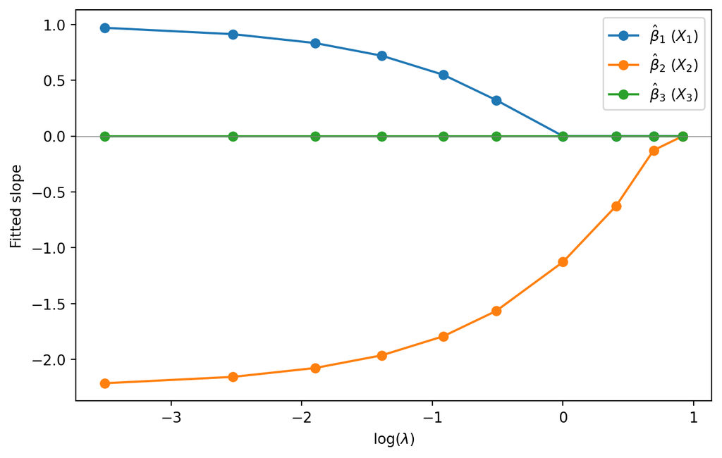

Figure 2: Lasso coefficient path vs. $\log(\lambda)$, coordinate descent with warm starts.

As $\lambda$ decreases from $2.5$ toward $0.03$ (equivalently, moving toward more negative $\log\lambda$, since $\log(2.5)\approx 0.92$ and $\log(0.03)\approx -3.51$), the covariates enter the model in this order: $X_2$ first (nonzero already at $\lambda = 2.0$), then $X_1$ (nonzero starting at $\lambda = 0.6$), while $X_3$ never enters at any grid value. This order matches the sizes of the true coefficients: $|\beta_2| = 2.0 > |\beta_1| = 1.0 > |\beta_3| = 0$. Because the covariates are independent standard normals here (no near-collinearity as in Q1–Q2), the score $a_j = \frac{1}{n}x_j^\top \tilde y$ that drives the soft-threshold update is, in expectation, proportional to the true coefficient $\beta_j$; the covariate with the largest true effect produces the largest score and so is the first to exceed the shrinking penalty $\lambda$ and enter the model, with smaller true effects entering only once $\lambda$ has fallen further, and a zero true effect never entering (at least not from real signal — see part c).

#### Part c

Table 10: Lasso fit at the smallest grid penalty vs. least squares on the same standardized data.

|  | Lasso at $\lambda=0.03$ | OLS on standardized $X$ |
| --- | --- | --- |
| $\hat\beta_1$ | 0.97001 | 1.00755 |
| $\hat\beta_2$ | -2.21347 | -2.24449 |
| $\hat\beta_3$ | 0.00000 | 0.02833 |

$X_3$ has a true population coefficient of zero, and in this run it stays *exactly* zero at every grid value, including the smallest penalty $\lambda = 0.03$ — it never enters the path. This happens because $X_3$’s score $a_3 = \frac{1}{n}x_3^\top \tilde y$ never exceeds $0.03$ in absolute value for this particular sample, so the soft-threshold $S(a_3, 0.03) = \mathrm{sign}(a_3)(|a_3| - 0.03)_+$ is zero at every $\lambda$ tried.

Comparing the lasso fit at $\lambda = 0.03$ with ordinary least squares on the same standardized design: $\hat\beta_1 = 0.970$ (lasso) vs. $1.008$ (OLS), $\hat\beta_2 = -2.213$ (lasso) vs. $-2.244$ (OLS), and $\hat\beta_3 = 0$ (lasso) vs. $0.028$ (OLS, nonzero because OLS applies no penalty at all). The two fits are close but not identical for two related reasons. First, $\lambda = 0.03$ is small but strictly positive, so lasso still applies a small amount of soft-thresholding shrinkage to every coordinate — pulling $\hat\beta_1$ and $\hat\beta_2$ slightly toward zero relative to their unpenalized OLS values — which is why lasso’s magnitudes are both slightly smaller than OLS’s in absolute value. Second, and more visibly for $X_3$, lasso’s soft-threshold sets any coefficient whose score falls below $\lambda$ in absolute value to *exactly* zero, while OLS has no such mechanism and instead returns whatever small nonzero value ($0.028$) best fits the sampling noise in that column. As $\lambda \to 0$ the coordinate descent solution converges to the OLS solution exactly (since the penalty vanishes), so the residual gap seen here at $\lambda = 0.03$ reflects the last bit of shrinkage and thresholding still present at that grid’s smallest value.

## Question 4: Tuning and comparing penalized regressions for diabetes prediction

### Answer

#### Cross-validation results

Table 11: Selected penalty and cross-validation error for each method (10-fold CV on the supplied folds).

| Method | $\alpha_{\min}$ | CV MSE | CV SE |
| --- | --- | --- | --- |
| Lasso | 0.1000 | 3071.2469 | 240.3527 |
| Ridge | 0.5012 | 3073.4858 | 242.1468 |
| Elastic net (alpha = 0.5) | 0.0032 | 3073.4487 | 242.1001 |

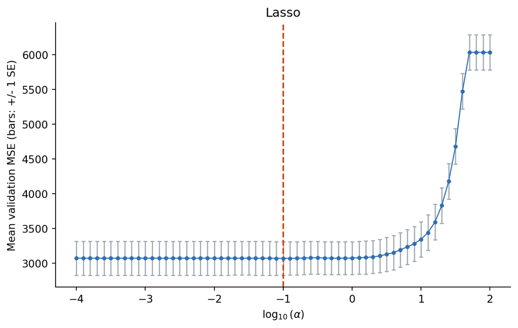

Figure 3: Cross-validation curve, Lasso: mean validation MSE vs. $\log_{10}(\alpha)$, with $\pm 1$ SE bars. Dashed line marks the selected penalty.

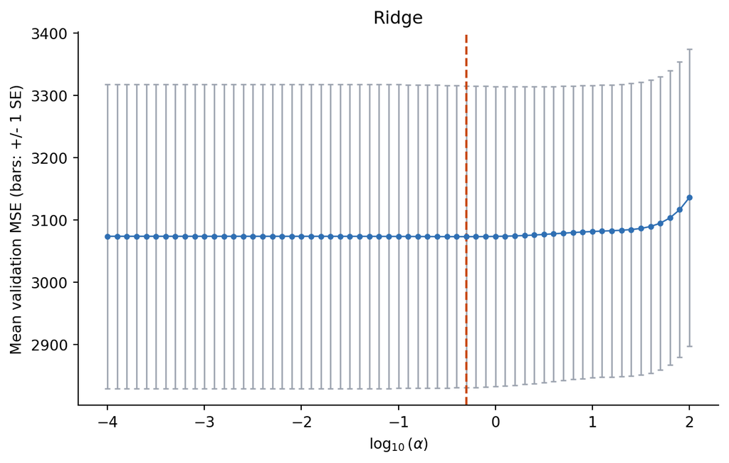

Figure 4: Cross-validation curve, Ridge.

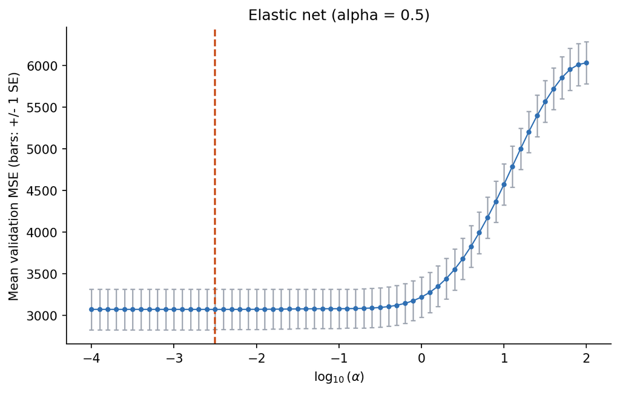

Figure 5: Cross-validation curve, Elastic net ($\alpha = 0.5$ mixing).

The three tuned fits are nearly indistinguishable: minimum cross-validation MSEs of about $3071.2$ (lasso), $3073.5$ (ridge), and $3073.4$ (elastic net), each with fold-based standard errors around $240$. The gap between the three methods is small compared with the displayed fold-to-fold variability — this descriptive comparison nominates a winner for this particular fold assignment, but it does not establish that any one method is truly superior for this prediction problem.

#### Selected model and final test evaluation

Table 12: Refit of the selected model on all training rows; test MSE evaluated once.

| Method | $\alpha$ | Nonzero coefs | Validation MSE | Training MSE | Test MSE |
| --- | --- | --- | --- | --- | --- |
| Lasso | 0.1 | 9 | 3071.2469 | 2908.3586 | 2732.4104 |

Selected covariates: `age`, `sex`, `bmi`, `bp`, `s1`, `s2`, `s4`, `s5`, `s6`.

Dropped: `s3`.

**Lasso** is the nominal winner, at a penalty of $\alpha \approx 0.10$. The selected fit keeps nine of the ten covariates (all but `s3`), with training MSE about $2908.4$ and a final test MSE of about $2732.4$ — evaluated exactly once, after the model and its penalty were already fixed by the cross-validation comparison, so this is an honest assessment of the complete selected procedure. The test error happens to fall slightly below the validation error here, but this ordering is itself a feature of this particular test split and could reverse under a different one. Because the comparison across lasso, ridge, and elastic net used the same ten folds throughout and the test rows were untouched until the method and penalty were both fixed, a different fold assignment could plausibly have nominated ridge or elastic net instead without changing anything about the validity of the procedure — the cross-validation table and plots, not the identity of the winner, are what justify the selection.